# Week 12 - Data Visualisation

Flora Le (flora.le@monash.edu)

2023-09-18

# 1 Intro

Throughout the semester, we have been exploring different methods to visualise data and communicate our analysis. This week we will dive a bit further into how to improve data visualisation and customise our graphs with ggplot.

# 2 Packages

```r
library(data.table)
library(psych)
library(car)
library(ggplot2)
library(JWileymisc)
library(extraoperators)
library(lm.beta)
library(visreg)
library(olsrr)
library(corrplot)
library(emmeans)
library(effectsize)
library(onewaytests)
library(dplyr)
```

# 3 Some useful packages for `ggplot`

```r
# install.packages(c("ggthemes", "ggpubr", "ggsci"))
library(ggthemes)
library(ggpubr)
library(ggsci)
```

# 4 Data

```r
source("week12_data.R")
```

# 5 Mapping Additional Variables

## 5.1 Univariate graphs

We have learnt how to make simple graphs like univariate graphs. We can map additional variables to aesthetics such as the colour to include more information.

*Example 1. Density Plot*

For density plots, separating by colour is easy, by adding another variable, say `Sex` as an additional aesthetic. For categorical aesthetics like color, if it had not already been a factor, its a good idea to convert it to a factor first.

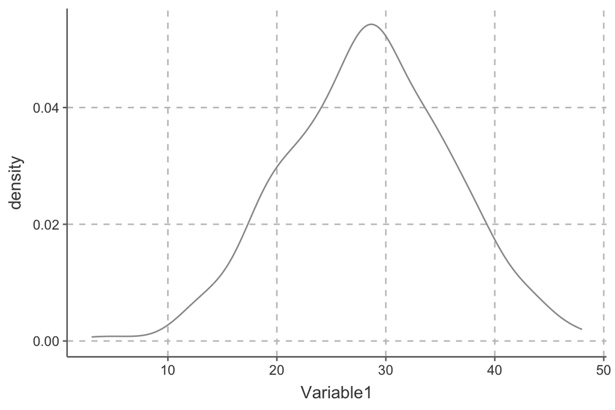

```r
# distribution of Variable 1
ggplot(d, aes(x = Variable1)) +
  geom_density()
```

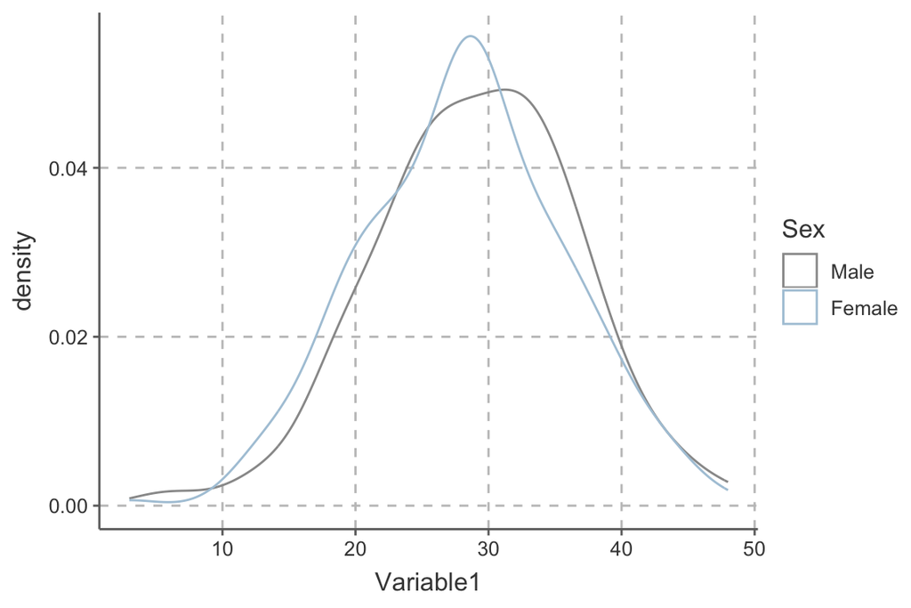

```r
# distribution of Variable 1 separated by Sex
ggplot(d, aes(x = Variable1, colour = Sex)) +
  geom_density()
```

*Example 2. Histogram*

For histograms, rather than control the colour of the lines, it is more helpful to control the fill colour. By default, the bars are stacked on top of each other. Overlapping bars can be dodged instead of stacked, by adding an additional argument `position = "dodge"`.

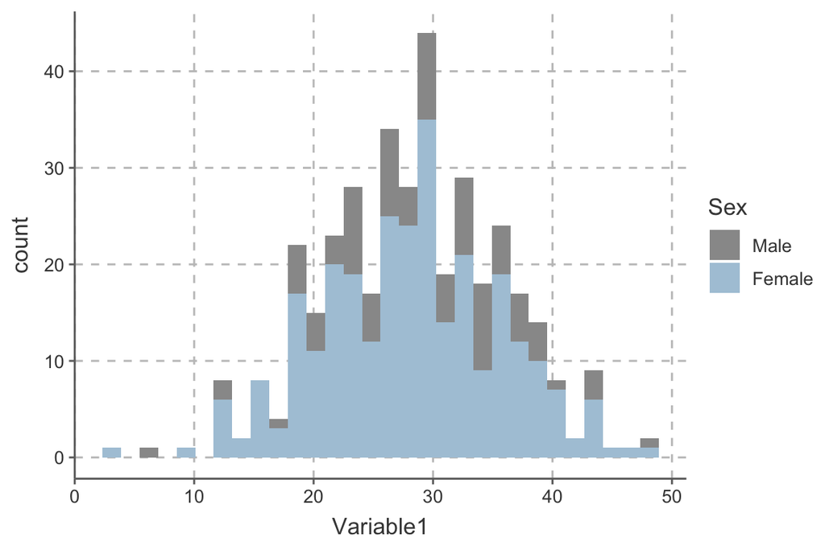

```r
# stacked bars
ggplot(d, aes(x = Variable1, fill = Sex)) +
  geom_histogram()
```

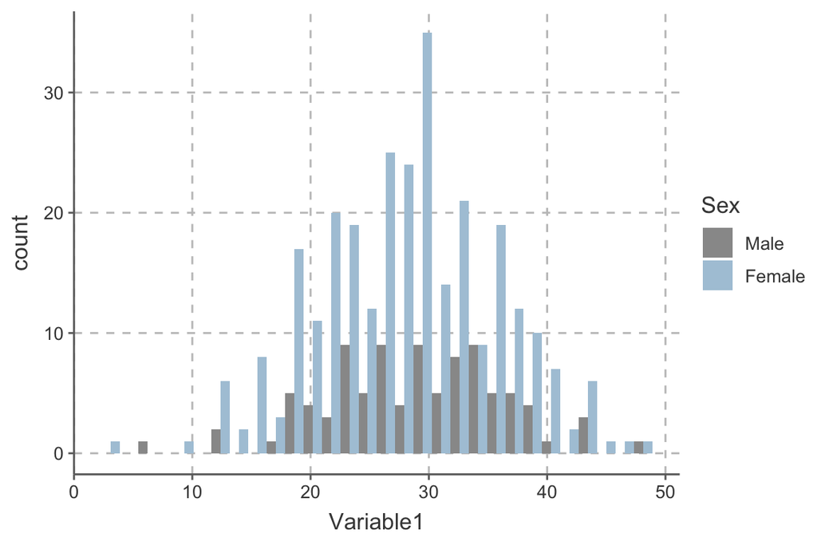

```r
# dodged bars
ggplot(d, aes(x = Variable1, fill = Sex)) +
  geom_histogram(position = "dodge")
```

## 5.2 Bivariate graphs

We can also map additional variables to our bivariate graphs.

*Example 3. Scatter plot*

As usual, we add colour to separate the relationship between `Variable1` and `Variable2` by `Sex`.

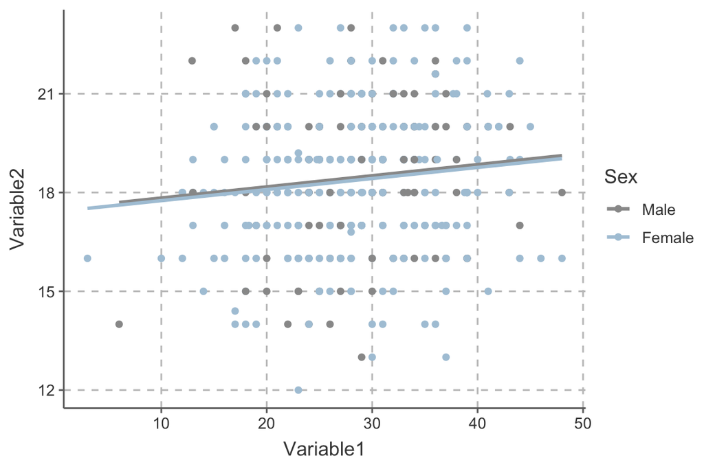

```r
ggplot(d,
       aes(
         x = Variable1,
         y = Variable2, colour = Sex)) +
  geom_point() +
  geom_smooth(method = 'lm', se = FALSE)
```

# 6 Improving Data Visualisation

When building a graph, it is helpful to think about what makes a good chart. Apart from selecting suitable chart types for our data, customising the axis, annotations, and the background (or commonly known as themes) can significantly improve the visualisation of your data.

You might have noticed that the graphs in the `.html` files are visually different from the graph we make during the workshops using the coded provided in the `.Rmd` file. This is because I have added other components to the graph, such as non-data components. Let’s look at how this works.

## 6.1 Linear Model Graph

This is the default version of a `visreg` graph presenting the relationship between Variable1 and Variable2.

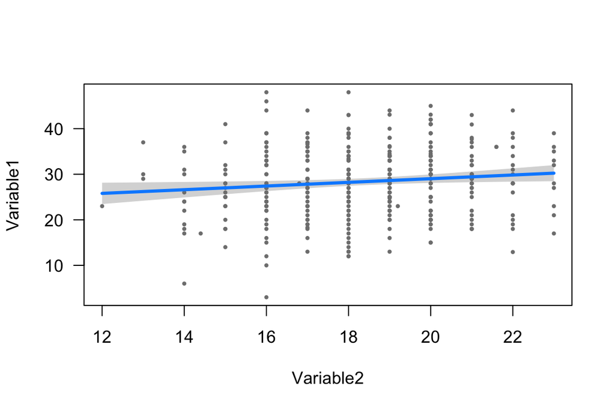

```r
visreg(ml, xvar = "Variable2")
```

To improve this graph, we first remove some elements that are not helpful on the graph, including the partial residuals and the rug (thin lines beside the axes displaying the distribution), by setting `partial = FALSE` and `rug = FALSE`.

Good labels are critical for making your plots accessible to a wider audience. We should always ensure the axis and legend labels display the full variable name. To modify our `visreg` graph, we first add an argument `gg = TRUE` to make it a ggplot. We then add our axis labels using the `ylab` and `xlab` functions. The `labs()` function also lets us name our axes and add a title to our graph.

We can also set a theme for the graph. `ggplot2` comes with a number of built in themes. Other nice themes can be found in packages such as `ggthemes` and `ggpubr`. We will use the `theme_classic()` for our graph today.

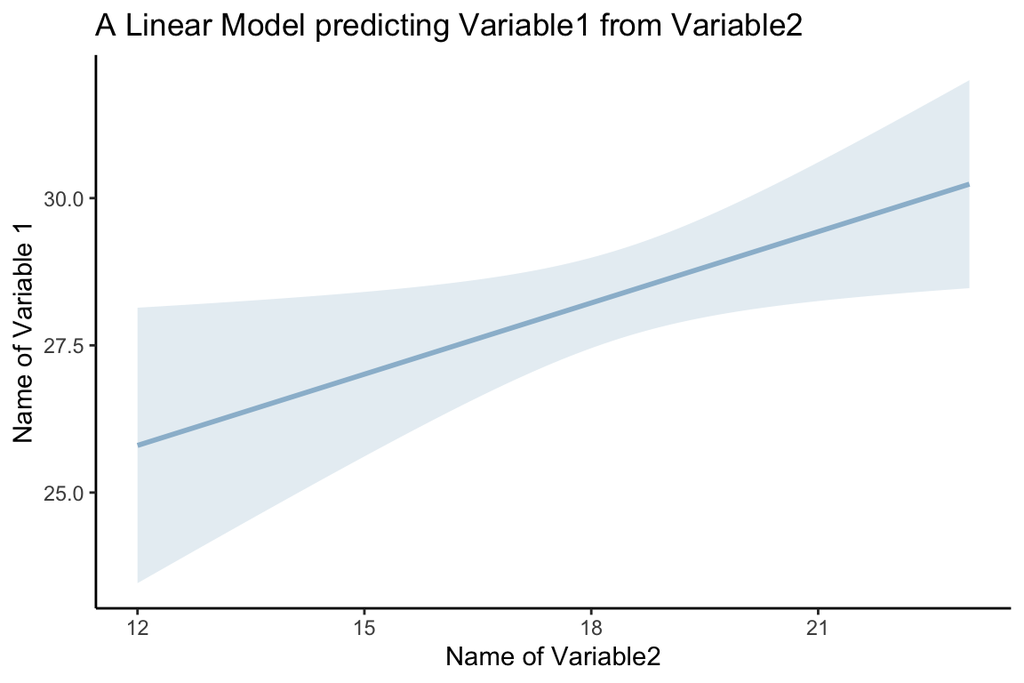

```r
visreg(ml, xvar = "Variable2", partial = FALSE, rug = FALSE, gg = TRUE,
       line.par = list(col = "#9BBBD2"),
       fill.par = list(fill = ggplot2::alpha("#ADC7DA", 0.3))) +
  labs(x = "Name of Variable2", y = "Name of Variable 1",
       title = "A Linear Model predicting Variable1 from Variable2") +
  theme_classic()
```

## 6.2 Moderation Graph

We can apply the same principles to our moderation graph. Here is the original graph showing the relationship between Variable2 and Variable1, moderated by Sex.

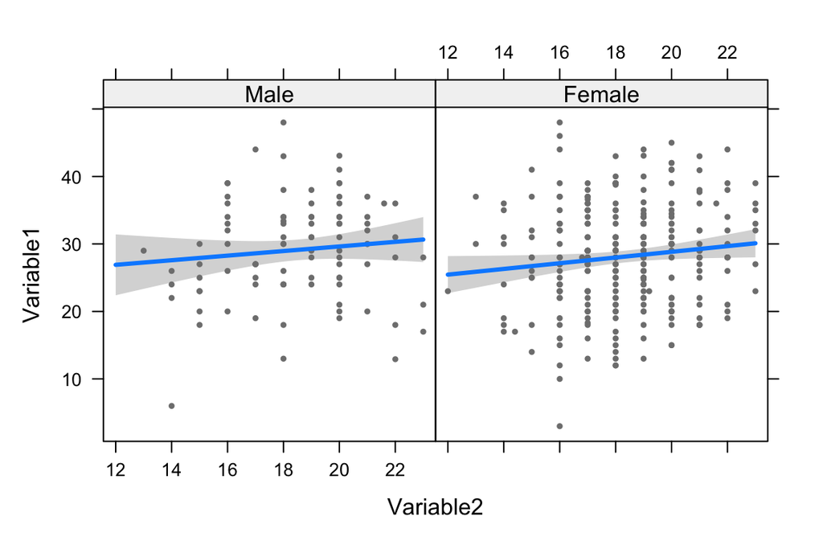

```r
visreg(mod,
       xvar = "Variable2", by = "Sex")
```

Coming to our non-data visual-enhancing components, we first overlay our slopes for females and males on top of each other by setting `overlay = TRUE`.

Instead of setting the colours manually, we can utilise the some colour palettes for `ggplot2` in `R`. For example, `ggsci` package offers a collection of color palettes inspired by colors used in scientific journals, data visualization libraries, science fiction movies, and TV shows. In this example, I used the `simpsons` palette, which is inspried by the colours used in The Simpsons. I added colour palettes for both slopes using `scale_color_simpsons()` and confidence intervals using `scale_fill_simpsons()`. I also adjusted level of transparency of the fill scale by setting `alpha = .2` (this value ranges from 0 to 1, with lower values corresponding to more transparent colors).

[Some other R colour palette recommendations](https://www.datanovia.com/en/blog/top-r-color-palettes-to-know-for-great-data-visualization/).

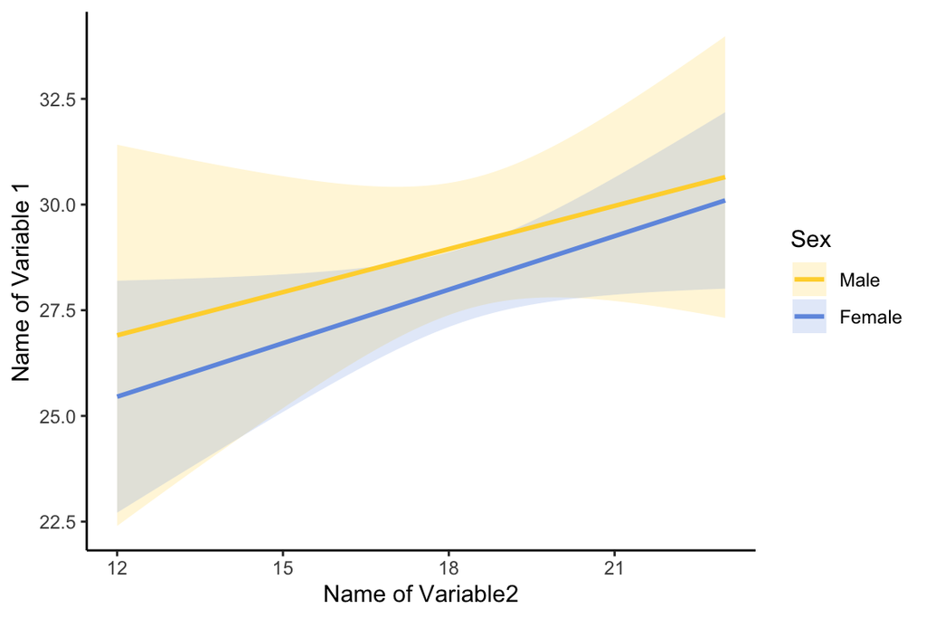

```r
visreg(mod,
       xvar = "Variable2", by = "Sex",
       overlay = TRUE, partial = FALSE, band = TRUE, rug = FALSE, gg = TRUE) +
  scale_color_simpsons() +
  scale_fill_simpsons(alpha = .2) +
  labs(x = "Name of Variable2", y = "Name of Variable 1") +
  theme_classic()
```

## 6.3 ANOVA Graph

For ANOVA graph, recall that we can use both `visreg` and `emmip` functions to present our results. We have learnt how to improve our `visreg` object, so in this example, let’s see how we can customise our `emmip` graph.

Here is the default graph showing how Variable1 varys according to Alcohol Risk and Sex.

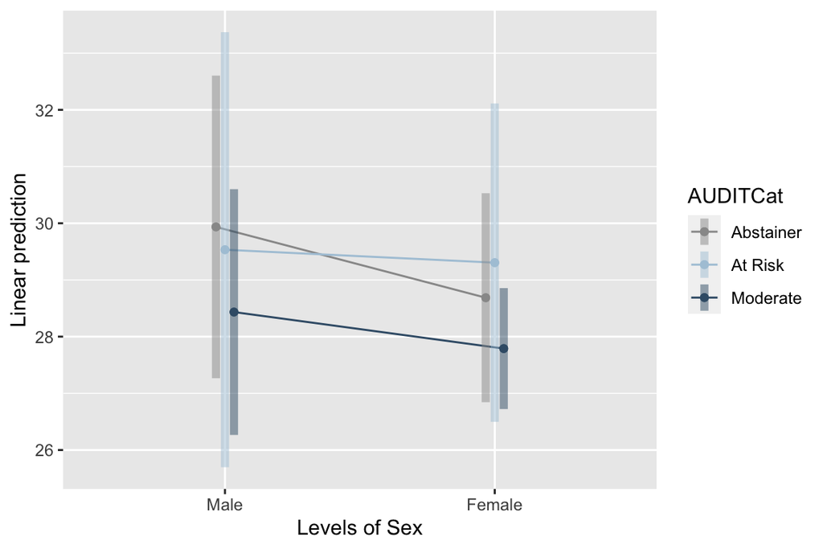

```r
emmip(em, AUDITCat ~ Sex, CIs = TRUE)
```

`emmip()` uses base ggplot so we can simply add layers to customise our graph. Let’s use the `jco` palette from `ggsci` this time. The `facet_grid()` function lets us lay out panels in a grid so we can separate our graph by alcohol risk groups.

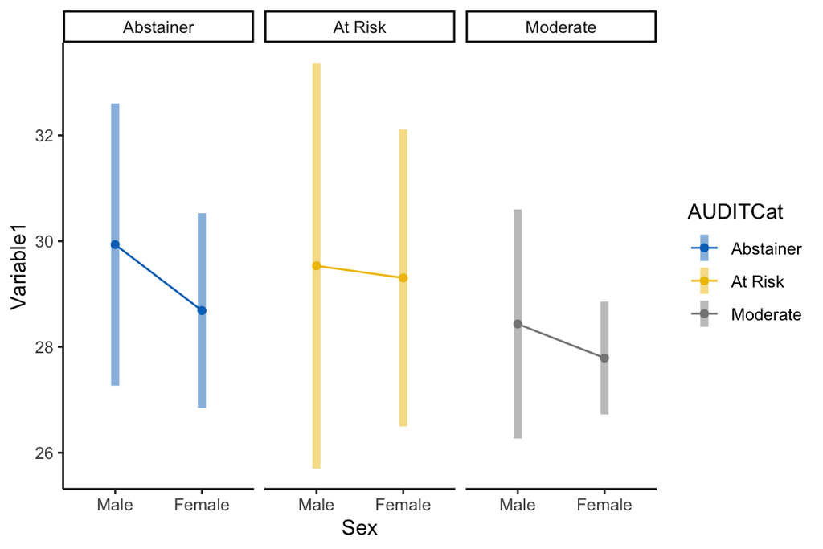

```r
emmip(em, AUDITCat ~ Sex, CIs = TRUE) +
  scale_color_jco() +
  labs(x = "Sex", y = "Variable1") +
  theme_classic() +
  facet_grid(~AUDITCat)
```

There are some redundant components in this graph. Since we have colour coded our results, we don’t really need the labels from facet plot. The ticks along the x-axis as well as the x-axis label are also not really important. We can make the background of our graph cleaner (less ink) using the `theme()` function.

First, we set `strip.text.x = element_blank()` to remove the labels from the facet plot. The `axis.ticks.x = element_blank()` can be added to remove the ticks on the axis. We can also adjust the position of our legend, for example, move it to the top with the `legend.position = "top"` argument.

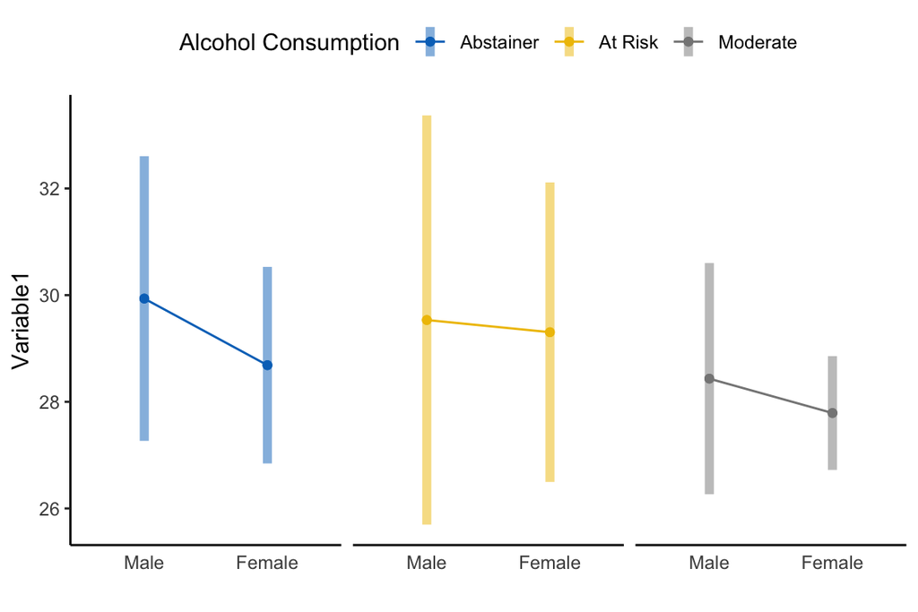

```r
emmip(em, AUDITCat ~ Sex, CIs = TRUE) +
  scale_color_jco() +
  labs(x = "", y = "Variable1") +
  guides(colour = guide_legend("Alcohol Consumption")) +
  theme_classic() +
  facet_grid(~AUDITCat) +
  theme(strip.text.x = element_blank(),
        axis.ticks.x = element_blank(),
        legend.position = "top")
```